# Telco Customer Churn Analysis

This notebook focuses on preparing the raw customer churn dataset for analysis and modeling. The goal is to create a clean, consistent, and reproducible dataset for subsequent steps.

The project Github repository is kushnertodd/telco-customer-churn.

This notebook is based on the following Towards Data Science project:  
[End-to-end machine learning project: Telco customer churn](https://towardsdatascience.com/end-to-end-machine-learning-project-telco-customer-churn-90744a8df97d/)

The dataset is derived from the [IBM Cognos Analytics 11.1.3+ Telco customer churn samples data module](https://community.ibm.com/community/user/blogs/steven-macko/2019/07/11/telco-customer-churn-1113).

## Data dictionary

These are the full set of data field descriptions for the IBM Cognos Analytics 11.1.3+ Telco customer churn samples data module. The samples data is located in the IBM Cognos Analytics installation under Team Content > Samples > Data in 5 [Excel spreadsheets](https://github.com/Pranjali-d/Telco_Customer_Churn_Analysis):

- Telco_customer_churn_demographics.xlsx
- Telco_customer_churn_location.xlsx
- Telco_customer_churn_population.xlsx
- Telco_customer_churn_services.xlsx
- Telco_customer_churn_status.xlsx

Each table field is described below.

### Demographics

| Field | Description | Values |
| --- | --- | --- |
| CustomerID | A unique ID that identifies each customer. |  |
| Gender | The customer's gender. | Male, Female |
| Age | The customer's current age, in years, at the time the fiscal quarter ended. |  |
| Under 30 | Indicates if the customer is under 30 years old. | Yes, No |
| Senior Citizen | Indicates if the customer is 65 or older. | Yes, No |
| Married | Indicates if the customer is married. | Yes, No |
| Dependents | Indicates if the customer lives with any dependents. Dependents could be children, parents, grandparents, etc. | Yes, No |
| Number of Dependents | Indicates the number of dependents that live with the customer. |  |

### Location

| Field | Description | Values |
| --- | --- | --- |
| Country | The country of the customer's primary residence. |  |
| State | The state of the customer's primary residence. |  |
| City | The city of the customer's primary residence. |  |
| Zip Code | The zip code of the customer's primary residence. |  |
| Lat Long | The combined latitude and longitude of the customer's primary residence. |  |
| Latitude | The latitude of the customer's primary residence. |  |
| Longitude | The longitude of the customer's primary residence. |  |

### Population

| Field | Description | Values |
| --- | --- | --- |
| Population | Estimated population in the customer’s Zip Code area. |  |

### Services

[output not shown]

### Status

[output not shown]

## Telco Customer Churn Analysis dataset

The [telco.csv](https://www.kaggle.com/datasets/alfathterry/telco-customer-churn-11-1-3) dataset contains a full set of data for the data dictionary. A version [WA_Fn-UseC_-Telco-Customer-Churn.csv](https://www.kaggle.com/datasets/blastchar/telco-customer-churn) reduced to the useful model variables contains:

- Customer ID
- Gender
- Senior Citizen
- Married
- Dependents
- Tenure in Months
- Phone Service
- Multiple Lines
- Internet Type
- Online Security
- Online Backup
- Device Protection Plan
- Premium Tech Support
- Streaming TV
- Streaming Movies
- Contract
- Paperless Billing
- Payment Method
- Monthly Charge
- Total Charges
- Customer Status

## Importing Required Libraries

Pandas is used for data manipulation and analysis. Display formatting is adjusted to improve readability when inspecting dataframes.

```python
import pandas as pd
# Display formatting
from IPython.core.display import HTML
HTML("""
<style>
.dataframe table, .dataframe th, .dataframe td { font-size: 12px; }
div.output_scroll { overflow-x: auto; }
</style>
""")
```

### Loading the Dataset

The dataset is loaded from the raw data directory. This raw version is kept unchanged to ensure data integrity and reproducibility.

```python
df = pd.read_csv("WA_Fn-UseC_-Telco-Customer-Churn.csv")
```

## Initial Data Inspection

At this stage, we inspect:

- Sample records
- The number of rows and columns
- Column names and data types
- Presence of missing values

This step helps build an initial understanding of the dataset before making any transformations.

```python
df.head()
```

|  | customerID | gender | SeniorCitizen | Partner | Dependents | tenure | PhoneService | MultipleLines | InternetService | OnlineSecurity | ... | DeviceProtection | TechSupport | StreamingTV | StreamingMovies | Contract | PaperlessBilling | PaymentMethod | MonthlyCharges | TotalCharges | Churn |
| --- | --- | --- | --- | --- | --- | --- | --- | --- | --- | --- | --- | --- | --- | --- | --- | --- | --- | --- | --- | --- | --- |
| 0 | 7590-VHVEG | Female | 0 | Yes | No | 1 | No | No phone service | DSL | No | ... | No | No | No | No | Month-to-month | Yes | Electronic check | 29.85 | 29.85 | No |
| 1 | 5575-GNVDE | Male | 0 | No | No | 34 | Yes | No | DSL | Yes | ... | Yes | No | No | No | One year | No | Mailed check | 56.95 | 1889.5 | No |
| 2 | 3668-QPYBK | Male | 0 | No | No | 2 | Yes | No | DSL | Yes | ... | No | No | No | No | Month-to-month | Yes | Mailed check | 53.85 | 108.15 | Yes |
| 3 | 7795-CFOCW | Male | 0 | No | No | 45 | No | No phone service | DSL | Yes | ... | Yes | Yes | No | No | One year | No | Bank transfer (automatic) | 42.30 | 1840.75 | No |
| 4 | 9237-HQITU | Female | 0 | No | No | 2 | Yes | No | Fiber optic | No | ... | No | No | No | No | Month-to-month | Yes | Electronic check | 70.70 | 151.65 | Yes |

5 rows × 21 columns

Shape of the dataset

```python
df.shape
```

```
(7043, 21)
```

### Reviewing Data Types

The dataset contains a mix of numerical and categorical variables. Many categorical features are currently stored as object types.

At this stage, no type conversion is performed. Detailed encoding and transformations will be handled during the feature engineering phase.

```python
df.info()
```

```
<class 'pandas.core.frame.DataFrame'>
RangeIndex: 7043 entries, 0 to 7042
Data columns (total 21 columns):
 #   Column            Non-Null Count  Dtype
---  ------            --------------  -----
 0   customerID        7043 non-null   object
 1   gender            7043 non-null   object
 2   SeniorCitizen     7043 non-null   int64
 3   Partner           7043 non-null   object
 4   Dependents        7043 non-null   object
 5   tenure            7043 non-null   int64
 6   PhoneService      7043 non-null   object
 7   MultipleLines     7043 non-null   object
 8   InternetService   7043 non-null   object
 9   OnlineSecurity    7043 non-null   object
 10  OnlineBackup      7043 non-null   object
 11  DeviceProtection  7043 non-null   object
 12  TechSupport       7043 non-null   object
 13  StreamingTV       7043 non-null   object
 14  StreamingMovies   7043 non-null   object
 15  Contract          7043 non-null   object
 16  PaperlessBilling  7043 non-null   object
 17  PaymentMethod     7043 non-null   object
 18  MonthlyCharges    7043 non-null   float64
 19  TotalCharges      7043 non-null   object
 20  Churn             7043 non-null   object
dtypes: float64(1), int64(2), object(18)
memory usage: 1.1+ MB
```

```python
df.dtypes.value_counts()
```

```
object     18
int64       2
float64     1
Name: count, dtype: int64
```

Checking the number of unique values of each column

```python
df.nunique()
```

```
customerID          7043
gender                 2
SeniorCitizen          2
Partner                2
Dependents             2
tenure                73
PhoneService           2
MultipleLines          3
InternetService        3
OnlineSecurity         3
OnlineBackup           3
DeviceProtection       3
TechSupport            3
StreamingTV            3
StreamingMovies        3
Contract               3
PaperlessBilling       2
PaymentMethod          4
MonthlyCharges      1585
TotalCharges        6531
Churn                  2
dtype: int64
```

Check statistics of the numeric fields in the data set

```python
df.describe()
```

|  | SeniorCitizen | tenure | MonthlyCharges |
| --- | --- | --- | --- |
| count | 7043.000000 | 7043.000000 | 7043.000000 |
| mean | 0.162147 | 32.371149 | 64.761692 |
| std | 0.368612 | 24.559481 | 30.090047 |
| min | 0.000000 | 0.000000 | 18.250000 |
| 25% | 0.000000 | 9.000000 | 35.500000 |
| 50% | 0.000000 | 29.000000 | 70.350000 |
| 75% | 0.000000 | 55.000000 | 89.850000 |
| max | 1.000000 | 72.000000 | 118.750000 |

### Identifying Missing Values

```python
df.isna().sum().sort_values(ascending=False)
```

```
customerID          0
DeviceProtection    0
TotalCharges        0
MonthlyCharges      0
PaymentMethod       0
PaperlessBilling    0
Contract            0
StreamingMovies     0
StreamingTV         0
TechSupport         0
OnlineBackup        0
gender              0
OnlineSecurity      0
InternetService     0
MultipleLines       0
PhoneService        0
tenure              0
Dependents          0
Partner             0
SeniorCitizen       0
Churn               0
dtype: int64
```

#### Total Charges (TotalCharges)

```python
# Convert empty strings and whitespace strings to NaN, then drop those rows
df["TotalCharges"] = pd.to_numeric(df["TotalCharges"], errors='coerce')
df = df.dropna(subset=["TotalCharges"])
df.shape
df.info()
df.dtypes.value_counts()
```

```
<class 'pandas.core.frame.DataFrame'>
Index: 7032 entries, 0 to 7042
Data columns (total 21 columns):
 #   Column            Non-Null Count  Dtype
---  ------            --------------  -----
 0   customerID        7032 non-null   object
 1   gender            7032 non-null   object
 2   SeniorCitizen     7032 non-null   int64
 3   Partner           7032 non-null   object
 4   Dependents        7032 non-null   object
 5   tenure            7032 non-null   int64
 6   PhoneService      7032 non-null   object
 7   MultipleLines     7032 non-null   object
 8   InternetService   7032 non-null   object
 9   OnlineSecurity    7032 non-null   object
 10  OnlineBackup      7032 non-null   object
 11  DeviceProtection  7032 non-null   object
 12  TechSupport       7032 non-null   object
 13  StreamingTV       7032 non-null   object
 14  StreamingMovies   7032 non-null   object
 15  Contract          7032 non-null   object
 16  PaperlessBilling  7032 non-null   object
 17  PaymentMethod     7032 non-null   object
 18  MonthlyCharges    7032 non-null   float64
 19  TotalCharges      7032 non-null   float64
 20  Churn             7032 non-null   object
dtypes: float64(2), int64(2), object(17)
memory usage: 1.2+ MB
```

```
object     17
int64       2
float64     2
Name: count, dtype: int64
```

```python
numeric_features = [feature for feature in df.columns if df[feature].dtype != 'O']
categorical_features = [feature for feature in df.columns if df[feature].dtype == 'O']

print('We have {} numerical features : {}'.format(len(numeric_features), numeric_features))
print('\nWe have {} categorical features : {}'.format(len(categorical_features), categorical_features))
```

```
We have 4 numerical features : ['SeniorCitizen', 'tenure', 'MonthlyCharges', 'TotalCharges']

We have 17 categorical features : ['customerID', 'gender', 'Partner', 'Dependents', 'PhoneService', 'MultipleLines', 'InternetService', 'OnlineSecurity', 'OnlineBackup', 'DeviceProtection', 'TechSupport', 'StreamingTV', 'StreamingMovies', 'Contract', 'PaperlessBilling', 'PaymentMethod', 'Churn']
```

#### Customer ID (customerID)

Customer ID is string, need not be converted.

#### Gender (gender)

Convert 'Male'/'Female' strings to 0/1

Plot churn distribution.

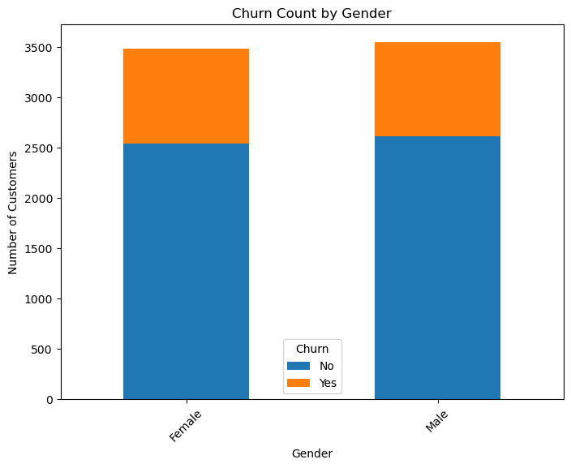

```python
import matplotlib.pyplot as plt
offer_churn = pd.crosstab(df.loc[df['gender'] != "None", 'gender'], df['Churn'])
offer_churn.plot(kind='bar', stacked=True, figsize=(8,6))
plt.title("Churn Count by Gender")
plt.xlabel("Gender")
plt.ylabel("Number of Customers")
plt.legend(title="Churn", labels=["No", "Yes"])
plt.xticks(rotation=45)
plt.show()
```

```python
df['gender_Encoded'] = df['gender'].map({'Male': 0, 'Female': 1}).astype('Int64')
print(df.loc[0:4, ['gender', 'gender_Encoded']])
```

```
   gender  gender_Encoded
0  Female               1
1    Male               0
2    Male               0
3    Male               0
4  Female               1
```

#### Senior Citizen (SeniorCitizen)

Senior Citizen is integer, need not be converted.

Plot churn distribution.

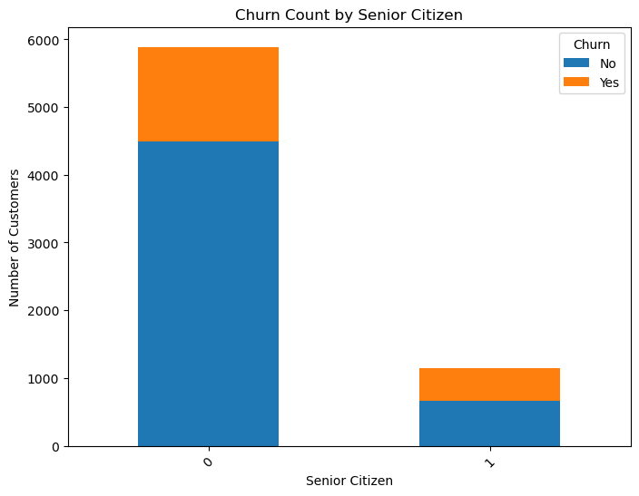

```python
import matplotlib.pyplot as plt
offer_churn = pd.crosstab(df.loc[df['SeniorCitizen'] != "None", 'SeniorCitizen'], df['Churn'])
offer_churn.plot(kind='bar', stacked=True, figsize=(8,6))
plt.title("Churn Count by Senior Citizen")
plt.xlabel("Senior Citizen")
plt.ylabel("Number of Customers")
plt.legend(title="Churn", labels=["No", "Yes"])
plt.xticks(rotation=45)
plt.show()
```

#### Married (Partner)

Convert 'No'/'Yes' strings to 0/1

Plot churn distribution.

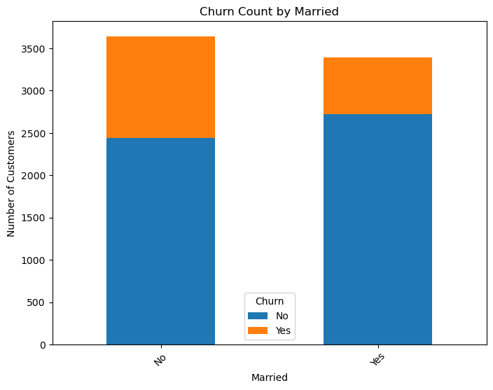

```python
import matplotlib.pyplot as plt
offer_churn = pd.crosstab(df.loc[df['Partner'] != "None", 'Partner'], df['Churn'])
offer_churn.plot(kind='bar', stacked=True, figsize=(8,6))
plt.title("Churn Count by Married")
plt.xlabel("Married")
plt.ylabel("Number of Customers")
plt.legend(title="Churn", labels=["No", "Yes"])
plt.xticks(rotation=45)
plt.show()
```

```python
df['Partner_Encoded'] = df['Partner'].map({'No': 0, 'Yes': 1}).astype('Int64')
print(df.loc[0:4, ['Partner', 'Partner_Encoded']])
```

```
  Partner  Partner_Encoded
0     Yes                1
1      No                0
2      No                0
3      No                0
4      No                0
```

#### Dependents (Dependents)

Convert 'No'/'Yes' strings to 0/1

Plot churn distribution.

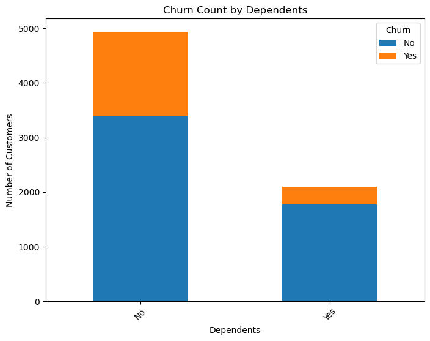

```python
import matplotlib.pyplot as plt
offer_churn = pd.crosstab(df.loc[df['Dependents'] != "None", 'Dependents'], df['Churn'])
offer_churn.plot(kind='bar', stacked=True, figsize=(8,6))
plt.title("Churn Count by Dependents")
plt.xlabel("Dependents")
plt.ylabel("Number of Customers")
plt.legend(title="Churn", labels=["No", "Yes"])
plt.xticks(rotation=45)
plt.show()
```

```python
df['Dependents_Encoded'] = df['Dependents'].map({'No': 0, 'Yes': 1}).astype('Int64')
print(df.loc[0:4, ['Dependents', 'Dependents_Encoded']])
```

```
  Dependents  Dependents_Encoded
0         No                   0
1         No                   0
2         No                   0
3         No                   0
4         No                   0
```

#### Tenure in Months (tenure)

Tenure in Months is integer, need not be converted.

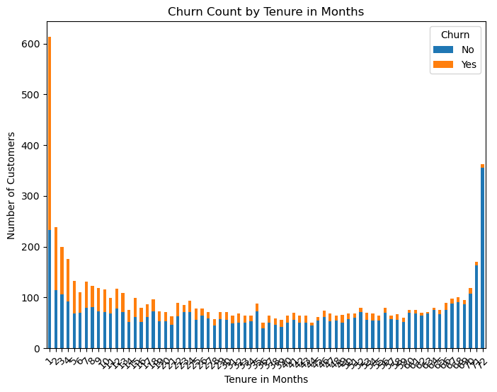

```python
import matplotlib.pyplot as plt
offer_churn = pd.crosstab(df.loc[df['tenure'] != "None", 'tenure'], df['Churn'])
offer_churn.plot(kind='bar', stacked=True, figsize=(8,6))
plt.title("Churn Count by Tenure in Months")
plt.xlabel("Tenure in Months")
plt.ylabel("Number of Customers")
plt.legend(title="Churn", labels=["No", "Yes"])
plt.xticks(rotation=45)
plt.show()
```

### Phone Service (PhoneService)

Convert 'No'/'Yes' strings to 0/1

Plot churn distribution.

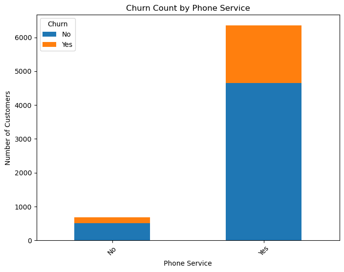

```python
import matplotlib.pyplot as plt
offer_churn = pd.crosstab(df.loc[df['PhoneService'] != "None", 'PhoneService'], df['Churn'])
offer_churn.plot(kind='bar', stacked=True, figsize=(8,6))
plt.title("Churn Count by Phone Service")
plt.xlabel("Phone Service")
plt.ylabel("Number of Customers")
plt.legend(title="Churn", labels=["No", "Yes"])
plt.xticks(rotation=45)
plt.show()
```

```python
df['PhoneService_Encoded'] = df['PhoneService'].map({'No': 0, 'Yes': 1}).astype('Int64')
print(df.loc[0:4, ['PhoneService', 'PhoneService_Encoded']])
```

```
  PhoneService  PhoneService_Encoded
0           No                     0
1          Yes                     1
2          Yes                     1
3           No                     0
4          Yes                     1
```

#### Multiple Lines (MultipleLines)

Convert 'No'/'Yes' strings to 0/1

Plot churn distribution.

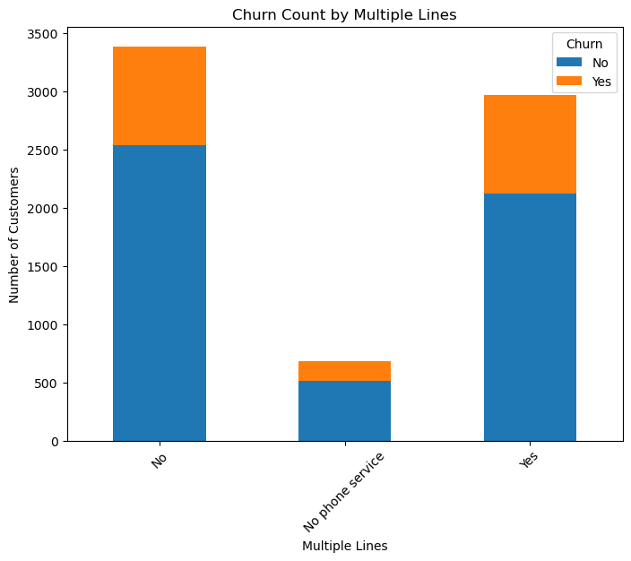

```python
import matplotlib.pyplot as plt
offer_churn = pd.crosstab(df.loc[df['MultipleLines'] != "None", 'MultipleLines'], df['Churn'])
offer_churn.plot(kind='bar', stacked=True, figsize=(8,6))
plt.title("Churn Count by Multiple Lines")
plt.xlabel("Multiple Lines")
plt.ylabel("Number of Customers")
plt.legend(title="Churn", labels=["No", "Yes"])
plt.xticks(rotation=45)
plt.show()
```

```python
df['MultipleLines_Encoded'] = df['MultipleLines'].map({'No': 0, 'No phone service': 0, 'Yes': 1})
print(df.loc[0:5, ['MultipleLines', 'MultipleLines_Encoded']])
```

```
      MultipleLines  MultipleLines_Encoded
0  No phone service                      0
1                No                      0
2                No                      0
3  No phone service                      0
4                No                      0
5               Yes                      1
```

#### Internet Type (InternetService)

Hot encode to 'InternetService_DSL', 'InternetService_Fiber optic', and 'InternetService_No' columns.

Plot churn distribution.

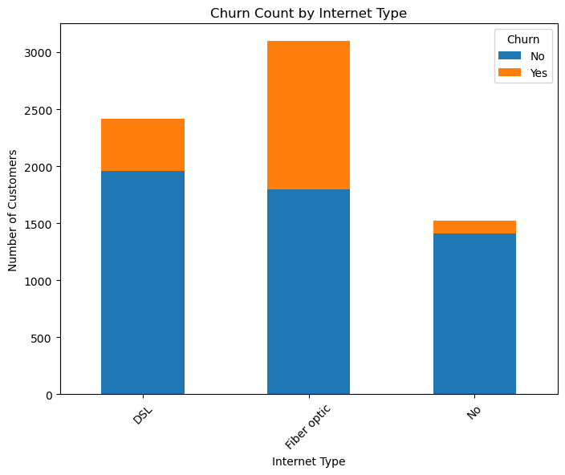

```python
import matplotlib.pyplot as plt
offer_churn = pd.crosstab(df.loc[df['InternetService'] != "None", 'InternetService'], df['Churn'])
offer_churn.plot(kind='bar', stacked=True, figsize=(8,6))
plt.title("Churn Count by Internet Type")
plt.xlabel("Internet Type")
plt.ylabel("Number of Customers")
plt.legend(title="Churn", labels=["No", "Yes"])
plt.xticks(rotation=45)
plt.show()
```

```python
import pandas as pd
print(df.loc[0:5, ['InternetService']])
df = pd.get_dummies(df, columns=['InternetService'], prefix='InternetService', dtype=int)
print(df.loc[0:5, ['InternetService_DSL', 'InternetService_Fiber optic', 'InternetService_No' ]])
```

```
  InternetService
0             DSL
1             DSL
2             DSL
3             DSL
4     Fiber optic
5     Fiber optic
   InternetService_DSL  InternetService_Fiber optic  InternetService_No
0                    1                            0                   0
1                    1                            0                   0
2                    1                            0                   0
3                    1                            0                   0
4                    0                            1                   0
5                    0                            1                   0
```

#### Online Security (OnlineSecurity)

Convert 'No'/'Yes' strings to 0/1

Plot churn distribution.

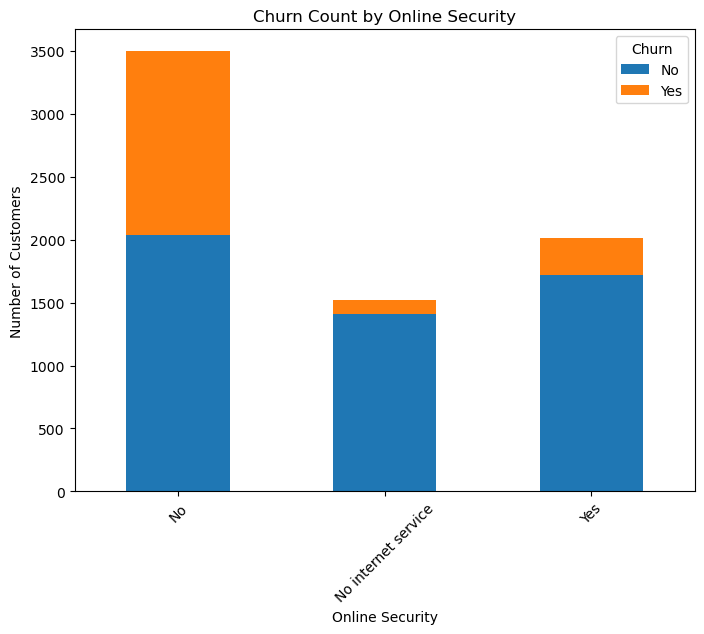

```python
import matplotlib.pyplot as plt
offer_churn = pd.crosstab(df.loc[df['OnlineSecurity'] != "None", 'OnlineSecurity'], df['Churn'])
offer_churn.plot(kind='bar', stacked=True, figsize=(8,6))
plt.title("Churn Count by Online Security")
plt.xlabel("Online Security")
plt.ylabel("Number of Customers")
plt.legend(title="Churn", labels=["No", "Yes"])
plt.xticks(rotation=45)
plt.show()
```

```python
df['OnlineSecurity_Encoded'] = df['OnlineSecurity'].map({'No': 0, 'No internet service': 0, 'Yes': 1}).astype('Int64')
print(df.loc[0:4, ['OnlineSecurity', 'OnlineSecurity_Encoded']])
```

```
  OnlineSecurity  OnlineSecurity_Encoded
0             No                       0
1            Yes                       1
2            Yes                       1
3            Yes                       1
4             No                       0
```

#### Online Backup (OnlineBackup)

Convert 'No'/'No internet service'/'Yes' strings to 0/0/1

Plot churn distribution.

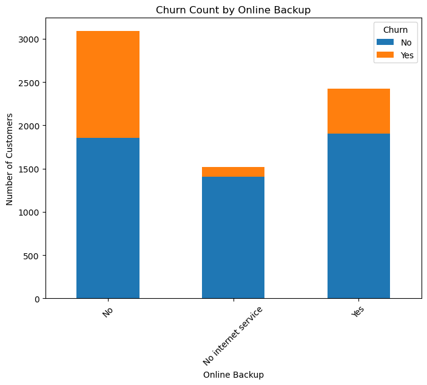

```python
import matplotlib.pyplot as plt
offer_churn = pd.crosstab(df.loc[df['OnlineBackup'] != "None", 'OnlineBackup'], df['Churn'])
offer_churn.plot(kind='bar', stacked=True, figsize=(8,6))
plt.title("Churn Count by Online Backup")
plt.xlabel("Online Backup")
plt.ylabel("Number of Customers")
plt.legend(title="Churn", labels=["No", "Yes"])
plt.xticks(rotation=45)
plt.show()
```

```python
df['OnlineBackup_Encoded'] = df['OnlineBackup'].map({'No': 0, 'No internet service': 0, 'Yes': 1}).astype('Int64')
print(df.loc[0:4, ['OnlineBackup', 'OnlineBackup_Encoded']])
```

```
  OnlineBackup  OnlineBackup_Encoded
0          Yes                     1
1           No                     0
2          Yes                     1
3           No                     0
4           No                     0
```

#### Device Protection Plan (DeviceProtection)

Convert 'No'/'No internet service'/'Yes' strings to 0/0/1

Plot churn distribution.

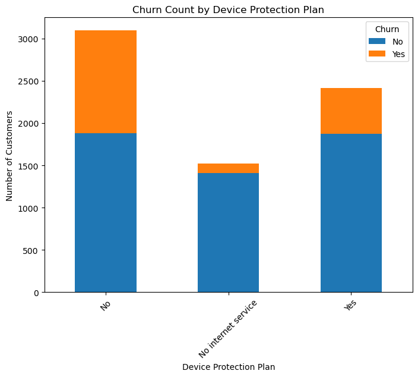

```python
import matplotlib.pyplot as plt
offer_churn = pd.crosstab(df.loc[df['DeviceProtection'] != "None", 'DeviceProtection'], df['Churn'])
offer_churn.plot(kind='bar', stacked=True, figsize=(8,6))
plt.title("Churn Count by Device Protection Plan")
plt.xlabel("Device Protection Plan")
plt.ylabel("Number of Customers")
plt.legend(title="Churn", labels=["No", "Yes"])
plt.xticks(rotation=45)
plt.show()
```

```python
df['DeviceProtection_Encoded'] = df['DeviceProtection'].map({'No': 0, 'No internet service': 0, 'Yes': 1}).astype('Int64')
print(df.loc[0:4, ['DeviceProtection', 'DeviceProtection_Encoded']])
```

```
  DeviceProtection  DeviceProtection_Encoded
0               No                         0
1              Yes                         1
2               No                         0
3              Yes                         1
4               No                         0
```

#### Premium Tech Support (TechSupport)

Convert 'No'/'No internet service'/'Yes' strings to 0/0/1

Plot churn distribution.

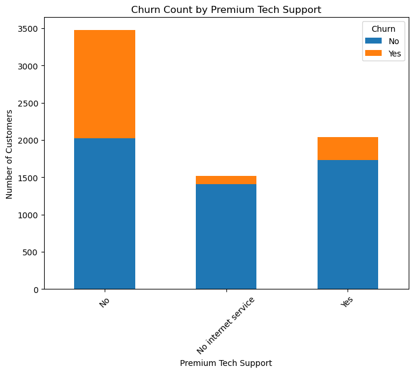

```python
import matplotlib.pyplot as plt
offer_churn = pd.crosstab(df.loc[df['TechSupport'] != "None", 'TechSupport'], df['Churn'])
offer_churn.plot(kind='bar', stacked=True, figsize=(8,6))
plt.title("Churn Count by Premium Tech Support")
plt.xlabel("Premium Tech Support")
plt.ylabel("Number of Customers")
plt.legend(title="Churn", labels=["No", "Yes"])
plt.xticks(rotation=45)
plt.show()
```

```python
df['TechSupport_Encoded'] = df['TechSupport'].map({'No': 0, 'No internet service': 0, 'Yes': 1}).astype('Int64')
print(df.loc[0:4, ['TechSupport', 'TechSupport_Encoded']])
```

```
  TechSupport  TechSupport_Encoded
0          No                    0
1          No                    0
2          No                    0
3         Yes                    1
4          No                    0
```

#### Streaming TV (StreamingTV)

Convert 'No'/'No internet service'/'Yes' strings to 0/0/1

Plot churn distribution.

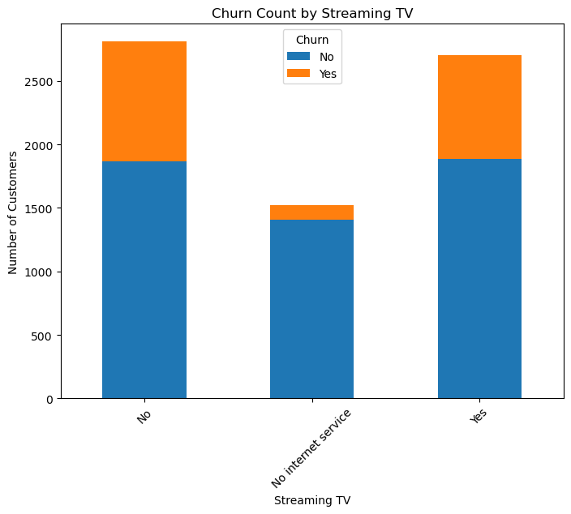

```python
import matplotlib.pyplot as plt
offer_churn = pd.crosstab(df.loc[df['StreamingTV'] != "None", 'StreamingTV'], df['Churn'])
offer_churn.plot(kind='bar', stacked=True, figsize=(8,6))
plt.title("Churn Count by Streaming TV")
plt.xlabel("Streaming TV")
plt.ylabel("Number of Customers")
plt.legend(title="Churn", labels=["No", "Yes"])
plt.xticks(rotation=45)
plt.show()
```

```python
df['StreamingTV_Encoded'] = df['StreamingTV'].map({'No': 0, 'No internet service': 0, 'Yes': 1}).astype('Int64')
print(df.loc[0:4, ['StreamingTV', 'StreamingTV_Encoded']])
```

```
  StreamingTV  StreamingTV_Encoded
0          No                    0
1          No                    0
2          No                    0
3          No                    0
4          No                    0
```

#### Streaming Movies (StreamingMovies)

Convert 'No'/'No internet service'/'Yes' strings to 0/0/1

Plot churn distribution.

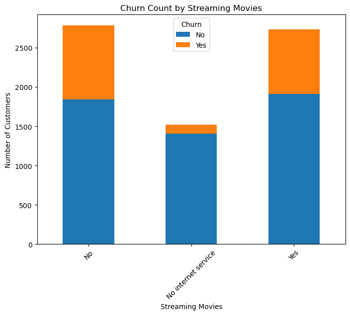

```python
import matplotlib.pyplot as plt
offer_churn = pd.crosstab(df.loc[df['StreamingMovies'] != "None", 'StreamingMovies'], df['Churn'])
offer_churn.plot(kind='bar', stacked=True, figsize=(8,6))
plt.title("Churn Count by Streaming Movies")
plt.xlabel("Streaming Movies")
plt.ylabel("Number of Customers")
plt.legend(title="Churn", labels=["No", "Yes"])
plt.xticks(rotation=45)
plt.show()
```

```python
df['StreamingMovies_Encoded'] = df['StreamingMovies'].map({'No': 0, 'No internet service': 0, 'Yes': 1}).astype('Int64')
print(df.loc[0:4, ['StreamingMovies', 'StreamingMovies_Encoded']])
```

```
  StreamingMovies  StreamingMovies_Encoded
0              No                        0
1              No                        0
2              No                        0
3              No                        0
4              No                        0
```

#### Contract (Contract)

Hot encode to 'Contract_Month-to-month', 'Contract_One year', and 'Contract_Two year' columns.

Plot churn distribution.

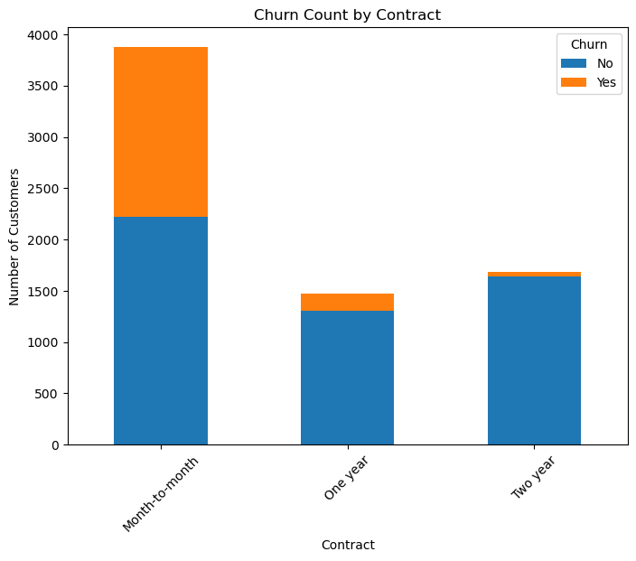

```python
import matplotlib.pyplot as plt
offer_churn = pd.crosstab(df.loc[df['Contract'] != "None", 'Contract'], df['Churn'])
offer_churn.plot(kind='bar', stacked=True, figsize=(8,6))
plt.title("Churn Count by Contract")
plt.xlabel("Contract")
plt.ylabel("Number of Customers")
plt.legend(title="Churn", labels=["No", "Yes"])
plt.xticks(rotation=45)
plt.show()
```

```python
import pandas as pd
print(df.loc[0:4, ['Contract']])
df = pd.get_dummies(df, columns=['Contract'], prefix='Contract', dtype=int)
print(df.loc[0:4, ['Contract_Month-to-month', 'Contract_One year', 'Contract_Two year']])
```

```
         Contract
0  Month-to-month
1        One year
2  Month-to-month
3        One year
4  Month-to-month
   Contract_Month-to-month  Contract_One year  Contract_Two year
0                        1                  0                  0
1                        0                  1                  0
2                        1                  0                  0
3                        0                  1                  0
4                        1                  0                  0
```

#### Paperless Billing (PaperlessBilling)

Convert 'No'/'Yes' strings to 0/1

Plot churn distribution.

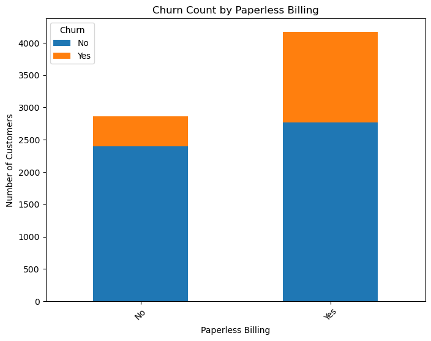

```python
import matplotlib.pyplot as plt
offer_churn = pd.crosstab(df.loc[df['PaperlessBilling'] != "None", 'PaperlessBilling'], df['Churn'])
offer_churn.plot(kind='bar', stacked=True, figsize=(8,6))
plt.title("Churn Count by Paperless Billing")
plt.xlabel("Paperless Billing")
plt.ylabel("Number of Customers")
plt.legend(title="Churn", labels=["No", "Yes"])
plt.xticks(rotation=45)
plt.show()
```

```python
df['PaperlessBilling_Encoded'] = df['PaperlessBilling'].map({'No': 0, 'Yes': 1}).astype('Int64')
print(df.loc[0:4, ['PaperlessBilling', 'PaperlessBilling_Encoded']])
```

```
  PaperlessBilling  PaperlessBilling_Encoded
0              Yes                         1
1               No                         0
2              Yes                         1
3               No                         0
4              Yes                         1
```

#### Payment Method (PaymentMethod)

Hot encode to 'PaymentMethod_Bank transfer (automatic)', 'PaymentMethod_Credit card (automatic)', 'PaymentMethod_Electronic check', and 'PaymentMethod_Mailed check' columns.

Plot churn distribution.

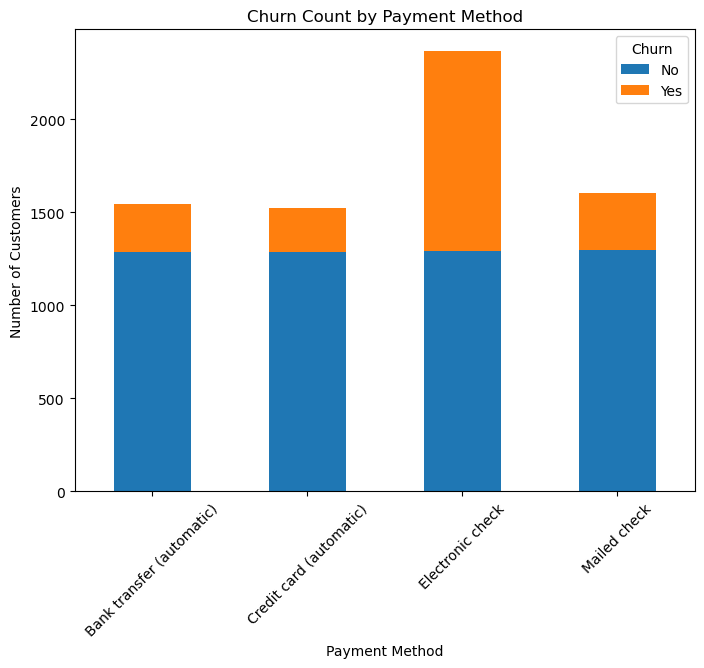

```python
import matplotlib.pyplot as plt
offer_churn = pd.crosstab(df.loc[df['PaymentMethod'] != "None", 'PaymentMethod'], df['Churn'])
offer_churn.plot(kind='bar', stacked=True, figsize=(8,6))
plt.title("Churn Count by Payment Method")
plt.xlabel("Payment Method")
plt.ylabel("Number of Customers")
plt.legend(title="Churn", labels=["No", "Yes"])
plt.xticks(rotation=45)
plt.show()
```

```python
import pandas as pd
print(df.loc[0:4, ['PaymentMethod']])
df = pd.get_dummies(df, columns=['PaymentMethod'], prefix='PaymentMethod', dtype=int)
print(df.loc[0:4, ['PaymentMethod_Bank transfer (automatic)', 'PaymentMethod_Credit card (automatic)', 'PaymentMethod_Electronic check', 'PaymentMethod_Mailed check']])
```

```
               PaymentMethod
0           Electronic check
1               Mailed check
2               Mailed check
3  Bank transfer (automatic)
4           Electronic check
   PaymentMethod_Bank transfer (automatic)  \
0                                        0
1                                        0
2                                        0
3                                        1
4                                        0

   PaymentMethod_Credit card (automatic)  PaymentMethod_Electronic check  \
0                                      0                               1
1                                      0                               0
2                                      0                               0
3                                      0                               0
4                                      0                               1

   PaymentMethod_Mailed check
0                           0
1                           1
2                           1
3                           0
4                           0
```

#### Monthly Charges (MonthlyCharges)

Normalize the values from 0.0 to 1.0.

Plot churn distribution.

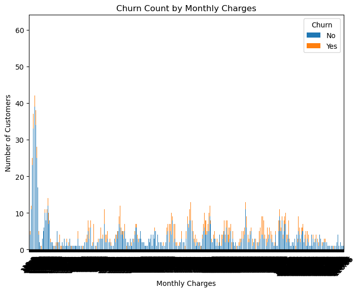

```python
import matplotlib.pyplot as plt
offer_churn = pd.crosstab(df.loc[df['MonthlyCharges'] != "None", 'MonthlyCharges'], df['Churn'])
offer_churn.plot(kind='bar', stacked=True, figsize=(8,6))
plt.title("Churn Count by Monthly Charges")
plt.xlabel("Monthly Charges")
plt.ylabel("Number of Customers")
plt.legend(title="Churn", labels=["No", "Yes"])
plt.xticks(rotation=45)
plt.show()
```

```python
print(df.loc[0:4, ['MonthlyCharges']])
MonthlyChargesMin = df['MonthlyCharges'].min()
MonthlyChargesMax = df['MonthlyCharges'].max()
print('MonthlyChargesMin = ', MonthlyChargesMin)
print('MonthlyChargesMax = ', MonthlyChargesMax)
df['MonthlyCharges'] = (df['MonthlyCharges'] - MonthlyChargesMin) / (MonthlyChargesMax - MonthlyChargesMin)
print(df.loc[0:4, ['MonthlyCharges']])
```

```
   MonthlyCharges
0           29.85
1           56.95
2           53.85
3           42.30
4           70.70
MonthlyChargesMin =  18.25
MonthlyChargesMax =  118.75
   MonthlyCharges
0        0.115423
1        0.385075
2        0.354229
3        0.239303
4        0.521891
```

#### Total Charges (TotalCharges)

Normalize the values from 0.0 to 1.0.

Plot churn distribution.

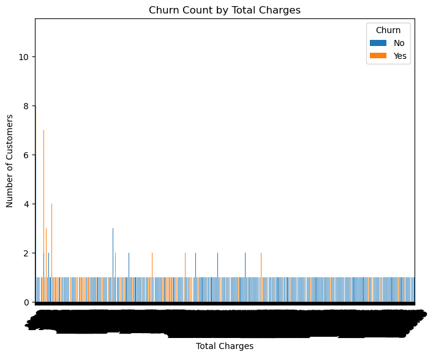

```python
import matplotlib.pyplot as plt
offer_churn = pd.crosstab(df.loc[df['TotalCharges'] != "None", 'TotalCharges'], df['Churn'])
offer_churn.plot(kind='bar', stacked=True, figsize=(8,6))
plt.title("Churn Count by Total Charges")
plt.xlabel("Total Charges")
plt.ylabel("Number of Customers")
plt.legend(title="Churn", labels=["No", "Yes"])
plt.xticks(rotation=45)
plt.show()
```

```python
print(df.loc[0:4, ['TotalCharges']])
TotalChargesMin = df['TotalCharges'].min()
TotalChargesMax = df['TotalCharges'].max()
print('TotalChargesMin = ', TotalChargesMin)
print('TotalChargesMax = ', TotalChargesMax)
df['TotalCharges'] = (df['TotalCharges'] - TotalChargesMin) / (TotalChargesMax - TotalChargesMin)
print(df.loc[0:4, ['TotalCharges']])
```

```
   TotalCharges
0         29.85
1       1889.50
2        108.15
3       1840.75
4        151.65
TotalChargesMin =  18.8
TotalChargesMax =  8684.8
   TotalCharges
0      0.001275
1      0.215867
2      0.010310
3      0.210241
4      0.015330
```

#### Churn Label (Churn)

Convert 'No'/'Yes' strings to 0/1

Plot churn distribution.

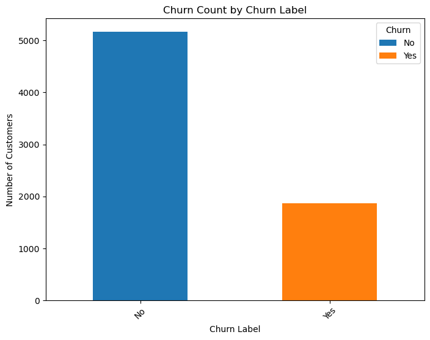

```python
import matplotlib.pyplot as plt
offer_churn = pd.crosstab(df.loc[df['Churn'] != "None", 'Churn'], df['Churn'])
offer_churn.plot(kind='bar', stacked=True, figsize=(8,6))
plt.title("Churn Count by Churn Label")
plt.xlabel("Churn Label")
plt.ylabel("Number of Customers")
plt.legend(title="Churn", labels=["No", "Yes"])
plt.xticks(rotation=45)
plt.show()
```

```python
df['Churn_Encoded'] = df['Churn'].map({'No': 0, 'Yes': 1}).astype('Int64')
print(df.loc[0:4, ['Churn', 'Churn_Encoded']])
```

```
  Churn  Churn_Encoded
0    No              0
1    No              0
2   Yes              1
3    No              0
4   Yes              1
```

### Saving the Cleaned Dataset

The cleaned dataset is saved to the processed data directory. This version will be used for exploratory data analysis and modeling.

```python
df.to_csv('cleaned_data.csv', index=False)
```